# Height estimates from DBH:Height relationship

Hardy Griesbauer

20/03/2020

## Estimating tree heights based on dbh:height relationships

In order to estimate stand-level volumes for each treatment, we need to first estimate heights for trees that do not have height measurements. We will do the following:

1. Model DBH:Height relationships separately for each measurement period, and for Bl:Sx separately (at first).
2. Compare Bl and Sx relationships, compare estimates between years, and determine if we can pool species and/or years to estimate Height.

### Step 1: Explore height:dbh relationships with scatterplots

First, let’s explore scatterplots for each species and measurement year:

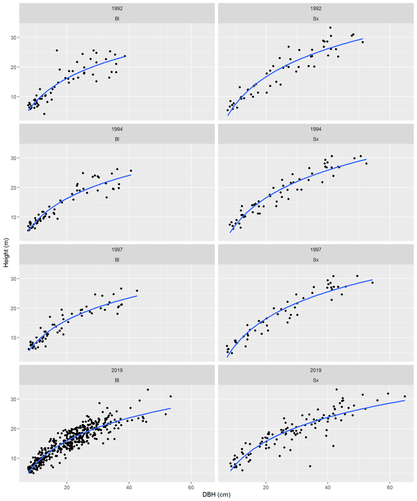

```r
  dat %>%
    filter(Species %in% c("Bl","Sx")) %>% # filter for Bl and Sx for now
    filter(Status=="Live") %>%
    drop_na(Height) %>% # remove trees where height was not measured

    # Plotting
  ggplot()+
  aes(x=DBH,y=Height,fill=Species)+
  geom_point()+
  facet_wrap(Year~Species,ncol=2)+
  theme(legend.position = "none")+
  ylab("Height (m)")+
  xlab("DBH (cm)")+
  geom_smooth(formula = y~log(x),method="lm",se=FALSE)
```

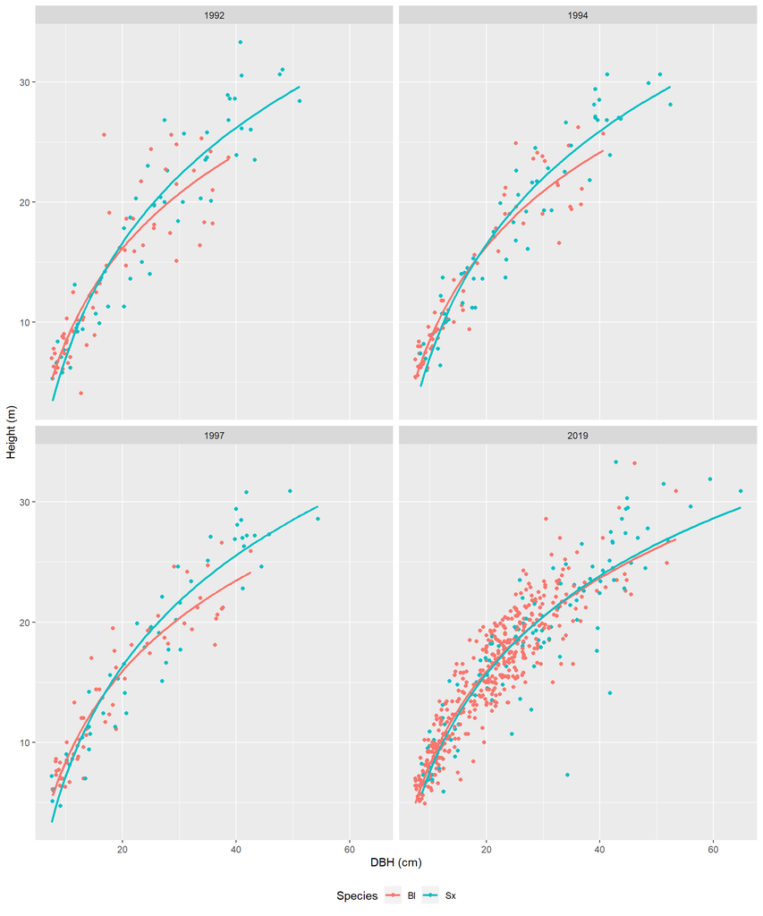

```r
  dat %>%
    filter(Species %in% c("Bl","Sx")) %>% # filter for Bl and Sx for now
    filter(Status=="Live") %>%
    drop_na(Height) %>% # remove trees where height was not measured

    # Plotting
  ggplot()+
  aes(x=DBH,y=Height,color=Species)+
  geom_point()+
  facet_wrap(~Year)+
  theme(legend.position = "bottom")+
  ylab("Height (m)")+
  xlab("DBH (cm)")+
  geom_smooth(formula = y~log(x),method="lm",se=FALSE)
```

We can see subtle differences between Bl and Sx DBH:Height relationships in first three measurement periods. By 2019, it looks like DBH:height relationships converged between the species.

Let’s look at differences between years by superposing different year graphs for species separately:

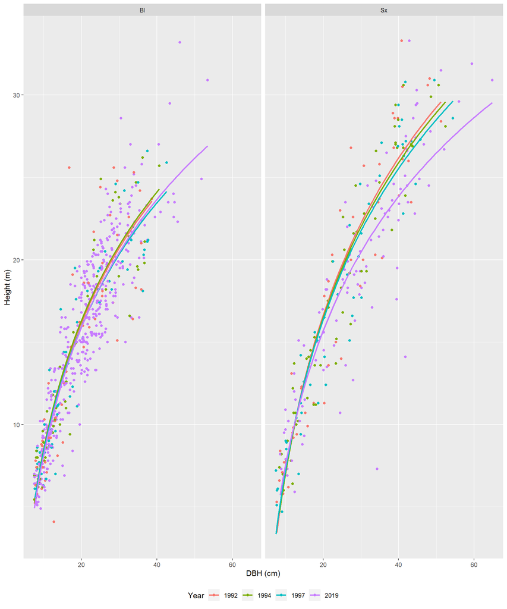

```r
  dat %>%
    filter(Species %in% c("Bl","Sx")) %>% # filter for Bl and Sx for now
    filter(Status=="Live") %>%
    drop_na(Height) %>% # remove trees where height was not measured

    # Plotting
  ggplot()+
  aes(x=DBH,y=Height,color=Year)+
  geom_point()+
  facet_wrap(~Species,ncol=2)+
  theme(legend.position = "bottom")+
  ylab("Height (m)")+
  xlab("DBH (cm)")+
  geom_smooth(formula = y~log(x),method="lm",se=FALSE)
```

Looks like Bl maintained the same DBH:Height relationship over all measurement periods. Sx 2019 relationship differs from other time periods.

### Can we pool species and measurement years?

I believe we can test this statistically:

*Note: I will get Peter Ott to confirm this is the correct way to test regression models between groups*

```r
# Assign data
x<-
   dat %>%
    filter(Species %in% c("Bl","Sx")) %>% # filter for Bl and Sx for now
    filter(Status=="Live") %>%
    drop_na(Height) # remove trees where height was not measured

# fit a model with all terms
mod.full<-lm(Height~log(DBH)+log(DBH):Species+log(DBH):Year+log(DBH):Species:Year,data=x)

# fit model with only DBH and species terms
mod.species<-lm(Height~log(DBH)+log(DBH):Species,data=x)

# fit model with only DBH and year terms
mod.year<-lm(Height~log(DBH)+log(DBH):Year,data=x)

# fit model with only DBH terms
mod.dbh<-lm(Height~log(DBH),data=x)

# Run through these iteratively
anova(mod.full,mod.dbh)
```

```
## Analysis of Variance Table
##
## Model 1: Height ~ log(DBH) + log(DBH):Species + log(DBH):Year + log(DBH):Species:Year
## Model 2: Height ~ log(DBH)
##   Res.Df    RSS Df Sum of Sq      F   Pr(>F)
## 1    874 5133.1
## 2    881 5269.9 -7    -136.8 3.3275 0.001669 **
## ---
## Signif. codes:  0 '***' 0.001 '**' 0.01 '*' 0.05 '.' 0.1 ' ' 1
```

Based on this ANOVA table, there is a significant reduction in residual sum of squares between the full model and the DBH-only model. The species+DBH and year+DBH models don’t seem to add much (not shown).

### Compare R<sup>2</sup> between models

How much variance is explained by each model? Summary below:

```r
rbind(data.frame(Model="full",broom::glance(mod.full)),
      data.frame(Model="dbh-only",broom::glance(mod.dbh)),
      data.frame(Model="dbh+species",broom::glance(mod.species)),
      data.frame(Model="dbh+year",broom::glance(mod.year))

      ) %>%
  dplyr::select(1:7)
```

```
##         Model r.squared adj.r.squared    sigma statistic p.value df
## 1        full 0.8585689     0.8572743 2.423457  663.2107       0  9
## 2    dbh-only 0.8547997     0.8546348 2.445763 5186.4787       0  2
## 3 dbh+species 0.8556795     0.8553515 2.439727 2608.7696       0  3
## 4    dbh+year 0.8575584     0.8569095 2.426552 1321.4828       0  5
```

Based on this, and the extremely modest increase in R<sup>2</sup> from DBH-only to full model, I’m tempted to say that we can pool all species and years into the most parsimonious (ie., DBH:Height) model. But definitely up for discussion!

### DBH:Height equation for pooled data

If we decide to use pooled data for the DBH:Height equation:

```r
paste("Predicted.Height = ",coef(mod.dbh)[2],
      " x ln(DBH) ",
      coef(mod.dbh)[1])
```

```
## [1] "Predicted.Height =  11.7910727851546  x ln(DBH)  -19.2060818133665"
```

Here are the coefficients from Mike’s analysis:

*Subalpine fir* HT = 11.188 x ln(DBH) - 17.609

*Hybrid white spruce* HT = 11.79 x ln(DBH) - 19.637

The coefficients using the pooled species/years are pretty similar to Mike’s formula for spruce.